# Midterm 2

Luke Letizia

April 8, 2018

### Question 1

A.

$\text{L} = \prod_{i=1}^ne^{\frac{y_i\theta_i-\text{b}(\theta_i)}{\phi_i}+\text{S}(y_i,\phi_i)}$

-I started the maximum likelihood procedure by taking the product of the function.

$\text{ln(L)} = \sum_{i=1}^n\frac{y_i\theta_i-\text{b}(\theta_i)}{\phi_i}+\text{S}(y_i\phi_i)$

-I then took the natural log of the product.

$\frac{\delta\text{L}}{\delta\underline\beta} = \underline0 = \sum_{i=1}^n\frac{(y_i-\text{b}^\prime(\theta_i)\frac{\delta\theta}{\delta\underline\beta})}{\phi_i}$

-Here I took the derivative of the function.

$=\sum_{i=1}^n\frac{y_i-\mu_i}{\text{Var[Y]}}*\text{b}^{\prime\prime}(\theta)*\frac{\delta\theta}{\delta\underline\beta}$

-Here I took the derivative of the function and then substituted the following values; $\phi = \frac{\text{Var[Y]}}{\text{b}^{\prime\prime}(\theta)}$ and $\text{b}^\prime(\theta) = \mu$

$=\sum_{i=1}^n\frac{y_i-\mu_i}{\text{Var[Y]}}(\frac{\delta\mu}{\delta\underline\beta})(\frac{\delta\underline\beta}{\delta\theta})*(\frac{\delta\theta}{\delta\underline\beta})$

-I also substituted the following value to solve for the simplest form; $\frac{\delta\mu}{\delta\underline\beta} = \frac{\delta\text{b}^\prime(\theta)}{\delta\underline\beta} = \text{b}^{\prime\prime}(\theta)\frac{\delta\theta}{\delta\underline\beta} <=> \text{b}^{\prime\prime}(\theta) = \frac{\delta\mu}{\delta\underline\beta} * \frac{\delta\underline\beta}{\delta\theta}$

$=\sum_{i=1}^n\frac{y_i-\mu_i}{\text{Var[Y]}}*\frac{\delta\mu}{\delta\underline\beta} = \underline0$

B.

$\text{L} = \prod_{i=1}^ne^{\frac{y_i\theta_i-\text{b}(\theta_i)}{\phi_i}+\text{S}(y_i,\phi_i)}$

-I started the maximum likelihood procedure by taking the product of the function.

$\text{ln(L)} = \sum_{i=1}^n\frac{y_i\theta_i-\text{b}(\theta_i)}{\phi_i}+\text{S}(y_i\phi_i)$

-I then took the natural log of the product.

$\frac{\delta\text{L}}{\delta\underline\beta} = 0 = \frac{\delta}{\delta\underline\beta_\text{L}}\sum_{i=1}^n \frac{y_i x_i^\text{T} \underline{\beta} - \text{b}^\prime(x_i^\text{T} \underline{\beta})}{\phi_i} + S(y_i, \phi_i)$

-Here I substituted $\theta_i$ values for $x_i^\text{T}\underline\beta$

$= \sum_{i=1}^n \frac{y_i x_{i\text{L}} - b^\prime(x_i^\text{T} \underline\beta x_{i\text{L}})}{\phi_i}$

-Here, I took the derivative of the log function.

$= \frac{1}{\phi}\sum_{i=1}^n (y_i - b^\prime(x_i^\text{T} \underline\beta)) x_{i\text{L}}w_i$

-I then substituted the following value and simplified; $\phi_i = \frac{\phi}{w_i}$

$= \sum_{i=1}^n (y_i - b^\prime(\underline\beta))*w_i$

-Setting $x_i = 1$ for $i = 1,2,...,n$, I got the following result.

$= \sum_{i=1}^n (y_i - \mu))*w_i = 0$

-I finally substituted $\text{b}^\prime(\underline\beta) = \mu$ and solve for $\hat{\mu}$

$\sum_{i=1}^n y_iw_i = \sum_{i=1}^n \mu*w_i <=> \hat{\mu} = \frac{\sum_{i=1}^ny_iw_i}{\sum_{i=1}^nw_i}$

C.

$g(\mu) = \theta$ & $\theta = \mu$

$\hat{\mu} = \hat{\mu} = \frac{\sum_{i=1}^ny_iw_i}{\sum_{i=1}^nw_i}$

$= \frac{\sum_{i=1}^ny_i}{n} = \bar{y}$

-By setting $w_i = 1$ we could solve for $\hat{\mu} = \bar{y}$

D.

$g(\mu) = \theta$ & $\theta = \text{log}\lambda$

$\mu = \text{b}^\prime(\theta) = e^\theta = e^{\text{log}\lambda} = \lambda$

$\hat{\mu} = \hat{\lambda} = \frac{\sum_{i=1}^ny_iw_i}{\sum_{i=1}^nw_i}$

-Here, I substituted $\hat{\mu}$, which we found in part b with the value of $\hat{\mu}$ which I found from a series of equivalences.

$= \frac{\sum_{i=1}^ny_i}{n} = \bar{y}$

-By setting $w_i = 1$ we could solve for $\hat{\lambda} = \bar{y}$

.

.

.

.

.

.

.

.

## Question 2

The summary of the data doesn’t really give us much information to go off of for the claim counts so we look at the histogram to get a better visualization of the data.

```
##    Min. 1st Qu.  Median    Mean 3rd Qu.    Max.
## 0.00000 0.00000 0.00000 0.06989 0.00000 3.00000
```

```
##     Min.  1st Qu.   Median     Mean  3rd Qu.     Max.
## 0.005476 0.279261 0.503764 0.519859 0.752909 1.000000
```

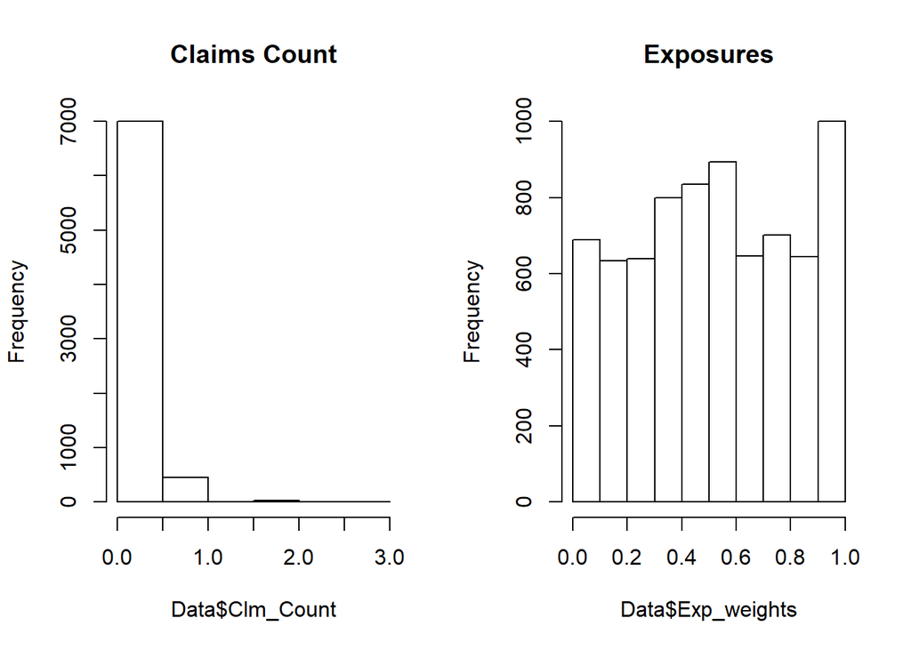

```
##  #Claims Observed
##        0     6996
##        1      455
##        2       28
##        3        4
```

### Implementing a Homogeneous Poisson Model

```
##  #Claims    Data Model without Exposure Model With Exposure
##     0.00 6996.00                6977.86             6983.05
##     1.00  455.00                 487.69              477.67
##     2.00   28.00                  17.04               21.52
##     3.00    4.00                   0.40                0.73
```

We can see that the model without exposure differs from the actual data observed. We can see that including exposures is necesarry for the model because it hones the values for each claim count closer to the observed values, but it is still not an adeqaute fit.

##### Chi Square Statistic without exposures:

```
## [1] 42
```

##### Chi Square Statistic with exposures:

```
## [1] 18
```

##### Don’t Know what this one is:

```
## [1] 6
```

We now investigate modeling different risk parameters for different drivers based on factors involved.

### Generalized Linear Poisson Model

##### Number of claims based on vehicle type:

```
##  #Claims   Auto  Other
##    0.000 92.530 94.507
##    1.000  7.054  5.054
##    2.000  0.390  0.357
##    3.000  0.026  0.082
```

##### Effects of vehicle age:

```
##      #Claims Age Cat 1: 0-2 Age Cat 2: 3-5 Age Cat 3: 6-10
## [1,]   0.000         92.351         91.829          94.372
## [2,]   1.000          7.104          7.652           5.303
## [3,]   2.000          0.454          0.519           0.325
## [4,]   3.000          0.091          0.000           0.000
##      Age Cat 4: 11-15 Age Cat 5: 16 and older
## [1,]           97.337                  98.165
## [2,]            2.577                   1.835
## [3,]            0.086                   0.000
## [4,]            0.000                   0.000
```

##### Effects on age of insured:

```
##      #Claims Age Cat 1: 22-25 Age Cat 2: 26-35 Age Cat 3: 36-45
## [1,]   0.000           92.908           91.734           93.201
## [2,]   1.000            6.383            7.791            6.271
## [3,]   2.000            0.709            0.407            0.528
## [4,]   3.000            0.000            0.068            0.000
##      Age Cat 4: 46-55 Age Cat 5: 56-65 Age Cat 6: 66 and over
## [1,]           93.843           89.172                 88.235
## [2,]            6.157           10.828                 11.765
## [3,]            0.000            0.000                  0.000
## [4,]            0.000            0.000                  0.000
```

##### Effects of the no claims discount:

```
##      #Claims     0    10    20    30    40    50
## [1,]    0.00 89.62 91.16 92.80 93.48 94.79 94.36
## [2,]    1.00  9.78  8.21  6.94  5.71  5.21  5.42
## [3,]    2.00  0.50  0.63  0.26  0.82  0.00  0.23
## [4,]    3.00  0.10  0.00  0.00  0.00  0.00  0.00
```

##### Comparing the models

```
##   #Claims    Data Model without Exposure Model With Exposure
## A    0.00 6996.00                6977.86             6983.05
## B    1.00  455.00                 487.69              477.67
## C    2.00   28.00                  17.04               21.52
## D    3.00    4.00                   0.40                0.73
##   Poisson Regression
## A            6986.94
## B             470.30
## C              24.63
## D               1.09
```

### Fit Negative Binomial

```
##
## Call:
## glm.nb(formula = Data$Clm_Count ~ Data$Exp_weights, data = Data,
##     init.theta = 1.446491164, link = log)
##
## Deviance Residuals:
##    Min      1Q  Median      3Q     Max
## -0.542  -0.428  -0.323  -0.256   3.600
##
## Coefficients:
##                  Estimate Std. Error z value Pr(>|z|)
## (Intercept)        -3.851      0.122   -31.6   <2e-16 ***
## Data$Exp_weights    1.985      0.169    11.8   <2e-16 ***
## ---
## Signif. codes:  0 '***' 0.001 '**' 0.01 '*' 0.05 '.' 0.1 ' ' 1
##
## (Dispersion parameter for Negative Binomial(1.4) family taken to be 1)
##
##     Null deviance: 2580.6  on 7482  degrees of freedom
## Residual deviance: 2431.2  on 7481  degrees of freedom
## AIC: 3723
##
## Number of Fisher Scoring iterations: 1
##
##
##               Theta:  1.446
##           Std. Err.:  0.589
##
##  2 x log-likelihood:  -3717.218
```

### Proofs

$E[N] = E[E[N|\theta]] = E[\theta\lambda] = \lambda E[\theta] = \lambda*1 = \lambda$

$Var[N] = E[N^2] - [E[N]]^2 = E[E[N^2|\theta]] - \lambda^2$

overdispersion is when there is a presence of a greater variability than should be expected.

```r
functn = function(Par, N, E) {
  lamb = Par[1]
  gam = Par[2]
NB = -sum(log((gamma(N+gam))/(gamma(gam)*factorial(N))*((1-((lamb * E)/(gam + (lamb * E))))^gam)*(((lamb * E)/(gam + (lamb * E)))^N)))
return(NB)
}

param = c(1, 1)
functn(Par = param, N = Data$Clm_Count, E = Data$Exp_weights)
```

```
## [1] 3516
```

```r
opt = optim(par = param, fn = functn, N = Data$Clm_Count, E = Data$Exp_weights)
opt
```

```
## $par
## [1] 0.13 1.42
##
## $value
## [1] 1852
##
## $counts
## function gradient
##       77       NA
##
## $convergence
## [1] 0
##
## $message
## NULL
```

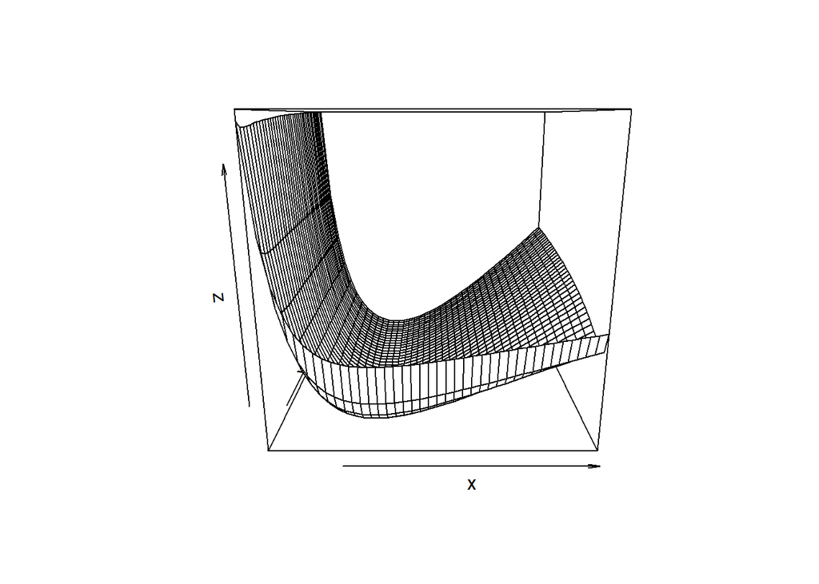

```r
Lambda = opt$par[1]
Gamma = opt$par[2]

z = matrix(data = NA, nrow = 40, ncol = 40)
x = seq(0.01, 0.4, 0.01)
y = seq(.04, 1.6, 0.04)
for(i in 1:length(x)){
  for(j in 1:length(y)){
    vector = c(x[i], y[j])
  z[i, j] = functn(Par = vector, N = Data$Clm_Count, E =   Data$Exp_weights)
  }
}
persp(x, y, z)
```

```r
##By the persp plot we can see that there is only in maximum and one minimum, so the optim values of the maximum values are the absolute maximums.
```

```r
Claims_NB_E=c()
for(i in 1:length(NrClaims)){
  N = unique(NrClaims[i])
  Claims_NB_E[i]=sum((gamma(N+Gamma))/(gamma(Gamma)*factorial(N))*((1-((Lambda * Data$Exp_weights)/(Gamma + (Lambda * Data$Exp_weights))))^Gamma)*(((Lambda * Data$Exp_weights)/(Gamma + (Lambda * Data$Exp_weights)))^N))
  }

options(digits=2)
Table=matrix(c(NrClaims, Claims,Claims_NB_E), length(Claims),3)
colnames(Table)=c("#Claims", "Data", "Model With Exposure"  )
rownames(Table)=c("","","","")
as.table(Table)
```

```
##  #Claims   Data Model With Exposure
##      0.0 6996.0              6997.3
##      1.0  455.0               451.0
##      2.0   28.0                32.1
##      3.0    4.0                 2.4
```

```r
## Comparing the models
options(digits=2)
Table=matrix(c(NrClaims, Claims, Claims_Poisson_GLM, Claims_NB_E), length(Claims),4)
colnames(Table)=c("#Claims", "Data", "Poisson Regression", "Negative Binomial"  )
as.table(Table)
```

```
##   #Claims   Data Poisson Regression Negative Binomial
## A     0.0 6996.0             6986.9            6997.3
## B     1.0  455.0              470.3             451.0
## C     2.0   28.0               24.6              32.1
## D     3.0    4.0                1.1               2.4
```

```r
## ==> We can see that the Negative Binomial is much more precise and closer to the actual data values than the Poisson Regression model is.

##Chi Squares
ChiSqSt_NB_E=sum((Claims-Claims_NB_E)^2/Claims_NB_E)
ChiSqSt_NB_E
```

```
## [1] 1.6
```

```r
ChiSqST_Poisson_GLM=sum((Claims-Claims_Poisson_GLM)^2/Claims_Poisson_GLM)
ChiSqST_Poisson_GLM
```

```
## [1] 8.7
```

```r
## ==> The Chi Square statistic for the Negative Binomial is much smaller than the Poisson Regression model's statistic which is evidence that the Negative Binomial differs much less from the actual data than Poisson.
```

# Estimated Dispersion

### Methods

Linders Consulting is implementing a Poisson regression model to describe the claim counts distribution. Because $\lambda$ is the parameter of a Poisson distribution and is the value for both the mean and variance, it may be inaccurate to assume all samples follow the same $\lambda$ variable. When the mean and variance are not equal in a counts distribution, there is an under or overdispersion, depending on if the variance is smaller or larger than the mean. The issue could be resolved by implementing a homogeneous negative binomial regression model. The variance is $\lambda(1+\lambda/\gamma)$ and mean of $\lambda$.